# All-null example from heart GTEX data

David Gerard

2016-06-09

# Abstract

I look at an all null dataset generated from the GTEX heart data. I look at variance inflation here.

# Data Generation

Read in heart GTEX, take a log, select top 1000 genes.

```r
datapath <- "../../data/gtex_tissue_gene_reads/heart.csv"
heart <- read.csv(datapath)
ngene <- 1000
lheart <- log(heart[, -c(1, 2)] + 1)
rm(heart)
exp_vec <- rowMeans(lheart)
gene_lab <- order(exp_vec, decreasing = TRUE)[1:ngene]
subgheart <- lheart[gene_lab, ]
nsamp <- 20
ncontrol <- 500
```

I’m going to run a small simulation study where I generate null data and use `qvalue` at every iteration on the p-values from RUV4, RUV4+inflation, CATE with negative controls and “calibration”, and CATE with negative controls without “calibration”. These are all very-similar methods. I use $n = $ 20 and $p = $ 1000. I will be using 500 control genes.

CATE calibrates their t-statistics by dividing by the median absolute deviation of the t-statistics. This can be seen as a type of variance inflation.

```r
itermax <- 100
qmat <- matrix(NA, nrow = itermax, ncol = 5)
colnames(qmat) <- c("ruv4", "ruv4inflate", "catenc_cal", "catenc_nocal", "seed")
for (index in 1:itermax) {
    set.seed(index)
    ind_pos <- sort(sample(1:ncol(subgheart), size = nsamp))
    sublheart <- subgheart[, ind_pos]
    dim(sublheart)

    condition <- rep(0, length = nsamp)
    condition[sample(1:length(condition), size = round(nsamp / 2))] <- 1
    X <- model.matrix(~condition)

    ctl <- rep(FALSE, length = ngene)
    ctl[sample(1:ngene, size = ncontrol)] <- TRUE

    num_sv <- sva::num.sv(dat = sublheart, mod = X)
    num_sv

    ruv4out    <- ruv::RUV4(Y = t(sublheart), X = X[, 2, drop = FALSE],
                            ctl = ctl, Z = X[, 1, drop = FALSE], k = num_sv)
    qmat[index, 1] <- qvalue::qvalue(ruv4out$p)$pi0

    ruv4inflate <- vicar::vicarius_ruv4(Y = t(sublheart), X = X, ctl = ctl, k = num_sv)
    qmat[index, 2] <- qvalue::qvalue(ruv4inflate$pvalue)$pi0

    catenc <- cate::cate(~condition, X.data = as.data.frame(X), Y = t(sublheart), r = num_sv,
                     nc = ctl, adj.method = "nc", calibrate = TRUE)
    qmat[index, 3] <- qvalue::qvalue(catenc$beta.p.value)$pi0

    catenc_f <- cate::cate(~condition, X.data = as.data.frame(X), Y = t(sublheart), r = num_sv,
                     nc = ctl, adj.method = "nc", calibrate = FALSE)
    qmat[index, 4] <- qvalue::qvalue(catenc_f$beta.p.value)$pi0

    qmat[index, 5] <- index ## the current seed
}
```

Now plot the estimates of $\pi_0$.

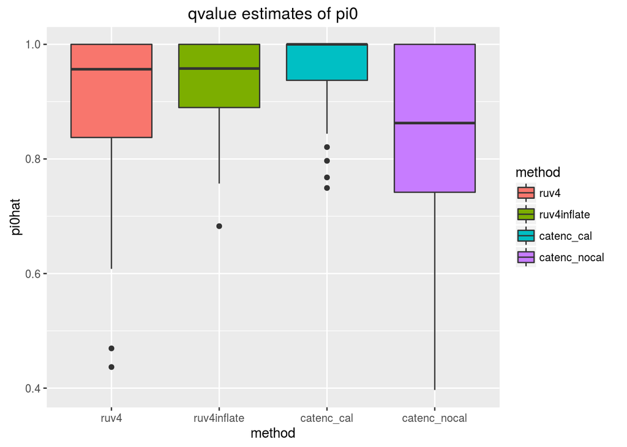

```r
library(reshape2)
library(ggplot2)

longdat <- melt(data = as.data.frame(qmat), id.vars = "seed")
colnames(longdat) <- c("seed", "method", "pi0hat")
ggplot(data = longdat, mapping = aes(y = pi0hat, x = method, fill = method)) +
    geom_boxplot() +
    ggtitle("qvalue estimates of pi0")
```

CATE with the calibration seems to do very well, but as I noted [earlier](http://dcgerard.github.io/succotash_sims/analysis/varyNsampNullpiLog2sd_cateonly.pdf), it usually over-inflates the t-statistics.

# Run Many Methods

Let’s look at where RUV4 does the worst

```r
current_seed <- which.min(qmat[, 1])
set.seed(current_seed)
ind_pos <- sort(sample(1:ncol(subgheart), size = nsamp))
sublheart <- subgheart[, ind_pos]
dim(sublheart)
```

```
## [1] 1000   20
```

```r
condition <- rep(0, length = nsamp)
condition[sample(1:length(condition), size = round(nsamp / 2))] <- 1
X <- model.matrix(~condition)


ncontrol <- 500
ctl <- rep(FALSE, length = ngene)
ctl[sample(1:ngene, size = ncontrol)] <- TRUE
```

```r
library(ashr)
library(sva)
num_sv <- sva::num.sv(dat = sublheart, mod = X)
num_sv
```

```
## [1] 3
```

```r
ruvashout  <- ash_ruv(Y = t(sublheart), X = X, ctl = ctl, k = num_sv,
                      likelihood = "t")
ruvashnorm <- ash_ruv(Y = t(sublheart), X = X, ctl = ctl, k = num_sv,
                      likelihood = "normal")
ruv4out    <- ruv::RUV4(Y = t(sublheart), X = X[, 2, drop = FALSE],
                        ctl = ctl, Z = X[, 1, drop = FALSE], k = num_sv)
svaout     <- sva::sva(dat = as.matrix(sublheart), mod = X, n.sv = 6)
```

```
## Number of significant surrogate variables is:  6
## Iteration (out of 5 ):1  2  3  4  5
```

```r
Xsv <- cbind(X, svaout$sv)
svout <- limma::eBayes(limma::lmFit(object = sublheart, design = Xsv))
caterr <- cate::cate(~condition, X.data = as.data.frame(X), Y = t(sublheart), r = num_sv)
catenc <- cate::cate(~condition, X.data = as.data.frame(X), Y = t(sublheart), r = num_sv,
                     nc = ctl, adj.method = "nc")
caterr_nocal <- cate::cate(~condition, X.data = as.data.frame(X), Y = t(sublheart), r = num_sv,
                     calibrate = FALSE)
catenc_nocal <- cate::cate(~condition, X.data = as.data.frame(X), Y = t(sublheart), r = num_sv,
                     nc = ctl, adj.method = "nc", calibrate = FALSE)
```

RUVASH using a t-likelihood seems to have perfect t-statistics.

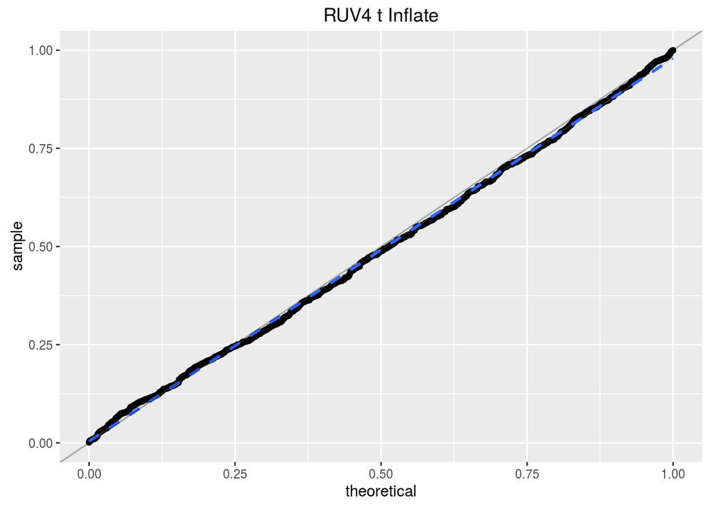

```r
library(ggplot2)
plot_qq <- function(p, title = "qq-unif") {
    df <- data.frame(sample = sort(p), theoretical = seq(0, 1, length = ngene))
    pl <- ggplot(df, aes(x = theoretical, y = sample)) +
        geom_point() +
        geom_smooth(method = lm, lty = 2, alpha = 0.5) +
        ggtitle(title) +
        geom_abline(slope = 1, intercept = 0, alpha = 0.3)
    print(pl)
}
plot_qq(p = ruvashout$ruv$pvalues, title = "RUV4 t Inflate")
```

The other versions of RUVASH overinflate. In the figures below, the blue dashed line is the linear regression line between the theoretical and sample quantiles. The gray line is the y = x line.

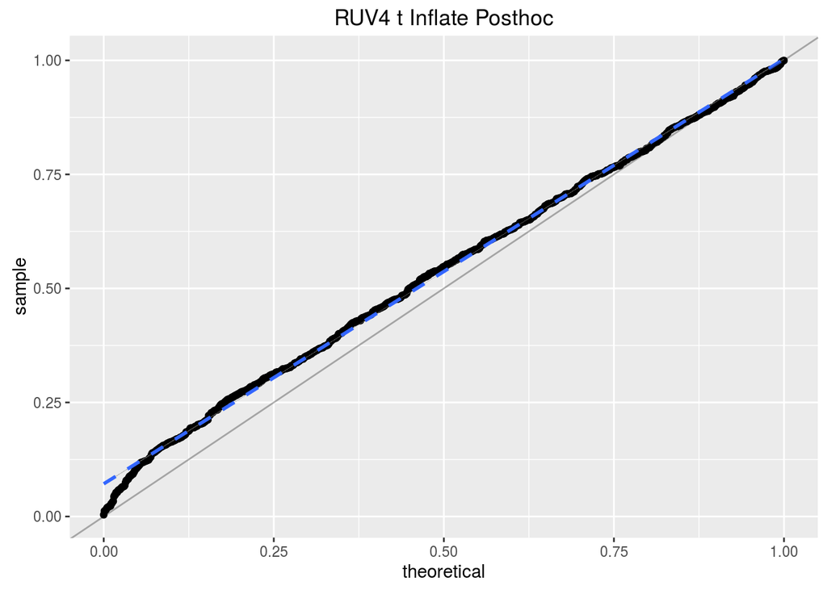

```r
plot_qq(p = ruvashout$ruv$pvalues_post, title = "RUV4 t Inflate Posthoc")
```

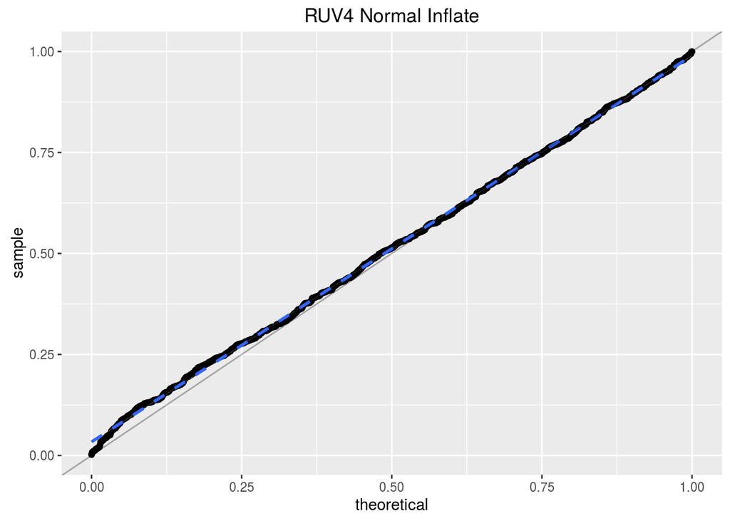

```r
plot_qq(p = ruvashnorm$ruv$pvalues, title = "RUV4 Normal Inflate")
```

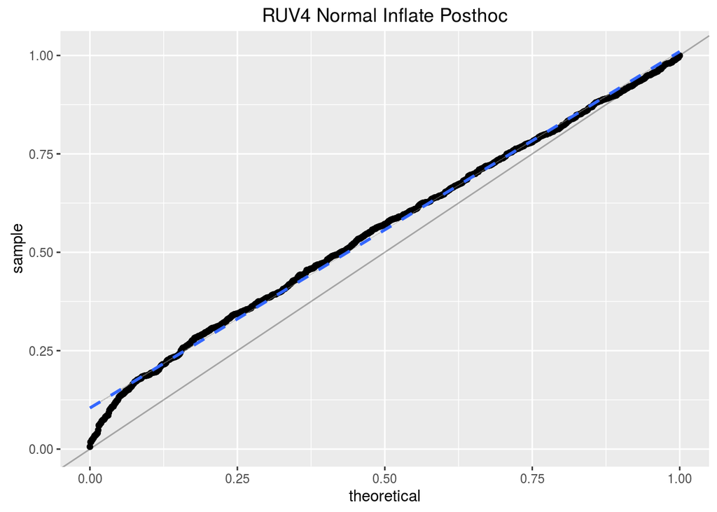

```r
plot_qq(p = ruvashnorm$ruv$pvalues_post, title = "RUV4 Normal Inflate Posthoc")
```

But they look a *lot* better than the p-values from RUV4 and SVA, which have p-values that are way to small.

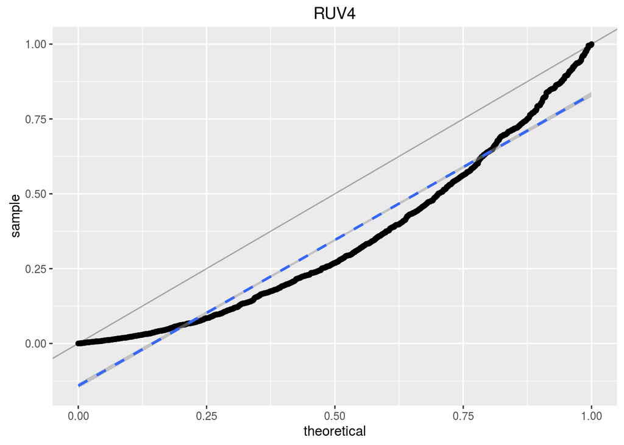

```r
plot_qq(p = ruv4out$p, title = "RUV4")
```

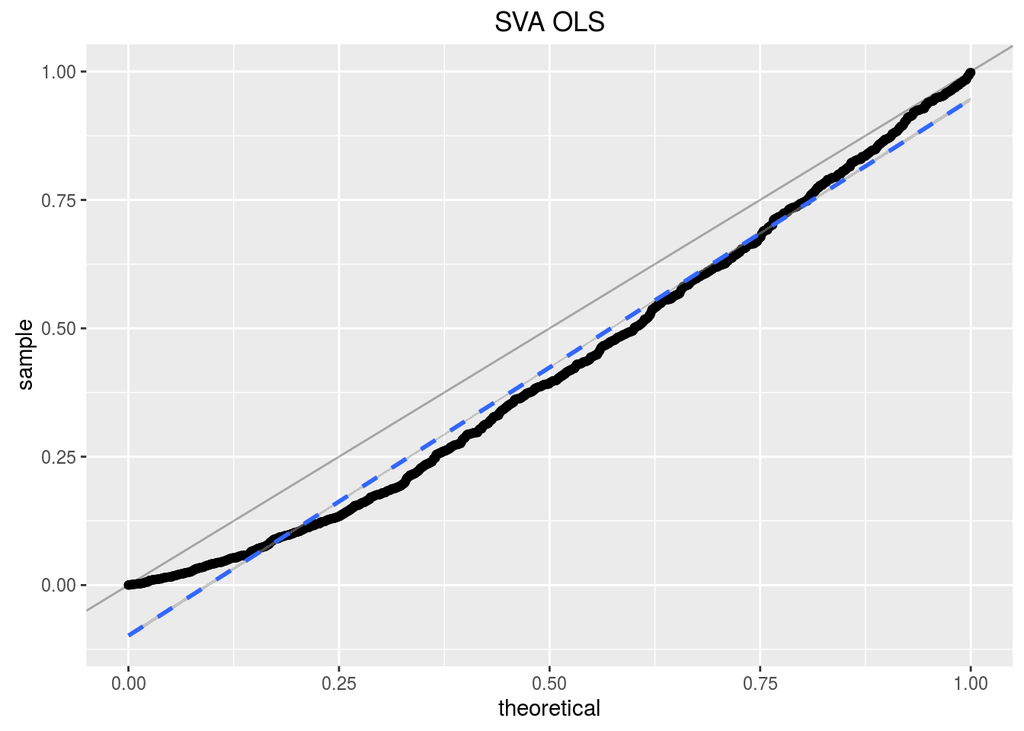

```r
plot_qq(p = svout$p.value[, 2], title = "SVA OLS")
```

The calibrated CATE p-values also look perfect.

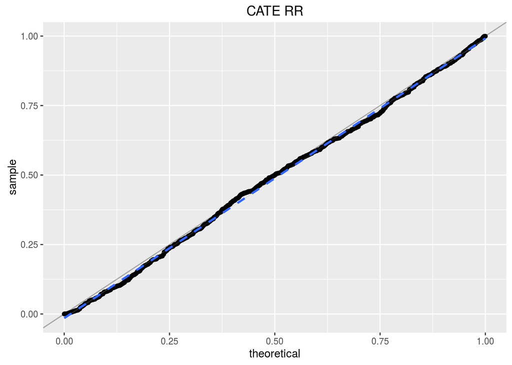

```r
plot_qq(caterr$beta.p.value, title = "CATE RR")
```

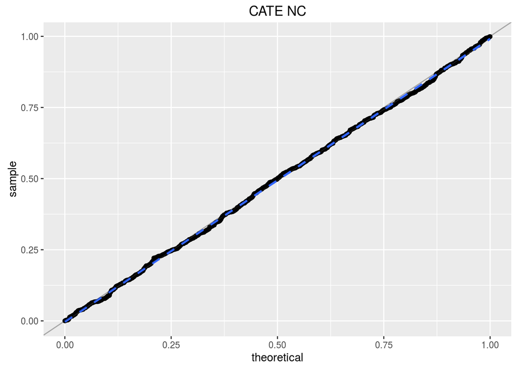

```r
plot_qq(catenc$beta.p.value, title = "CATE NC")
```

The uncalibrated CATE p-values look really bad

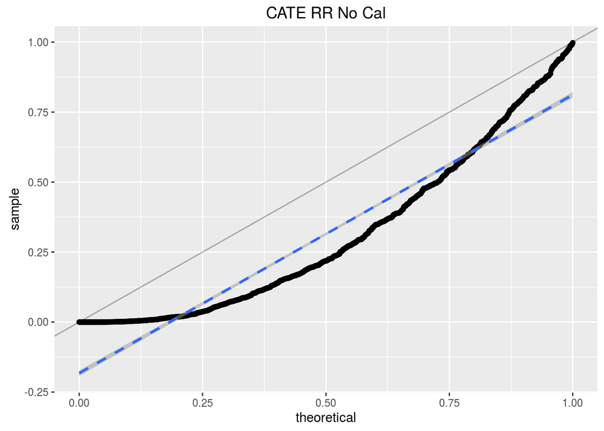

```r
plot_qq(caterr_nocal$beta.p.value, title = "CATE RR No Cal")
```

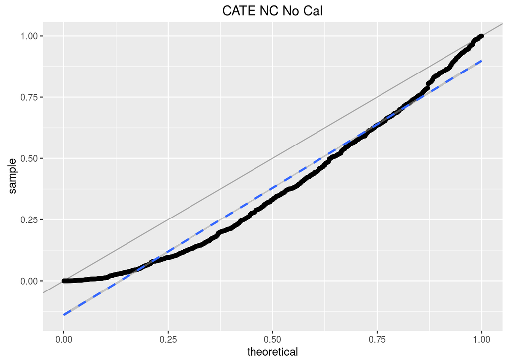

```r
plot_qq(catenc_nocal$beta.p.value, title = "CATE NC No Cal")
```